# Weather Radials

Jaeyoon Han

2016-03-26

## Creating weather radials with highcharter and ggplot2.

본 내용은 `highcharter` 패키지의 제작자인 [Joshua Kunst](http://jkunst.com)의 블로그의 포스트를 더 자세하게 재작성한 것임을 밝힌다.

본 작업에서는 다음의 다섯 가지의 패키지를 사용한다. 그 중 `highcharter`는 최근 등록된 패키지로 깃허브에서 계속해서 베타 버전이 개발되고 있어 깃허브 저장소를 통해 설치할 수도 있다. 이 경우 `devtool` 라이브러리를 불러와서 개발자 모드로 설치하면 된다. 이 경우 2016년 3월 26일 기준으로 0.2.0.9999 버전이 설치된다. 불편한 부분이 다소 있는데, 로컬 라이브러리에 설치되지 않기 때문에, R 세션을 실행할 때마다 설치해줘야 한다. 또한 설치가 된 상태더라도 `knitr`를 통해서 마크다운을 작성할 때 라이브러리 인식이 되지 않는다. 본인은 제작자의 깃허브에서 패키지를 받아 tar.gz 로 압축하여 로컬 라이브러리에 직접 설치해서 문제를 해결했다. 기존 저장소를 통해 받으려면 단순히 `install.packages("highcharter")`를 통해 설치하면 된지만, 본 예제에 있는 몇몇 함수들이 작동하지 않는다. 알아두길 바란다.

```r
library(devtools)
devtools::install_github("jbkunst/highcharter")
```

```r
library(highcharter)
library(ggplot2)
library(dplyr)
library(stringr)
library(lubridate)
```

데이터를 불러온다.

```r
weather <- tbl_df(read.csv("http://bl.ocks.org/bricedev/raw/458a01917183d98dff3c/sf.csv"))

weather
```

```
## Source: local data frame [365 x 23]
##
##         date Max.TemperatureC Mean.TemperatureC Min.TemperatureC
##       (fctr)            (int)             (int)            (int)
## 1   2014-1-1               13                 9                5
## 2   2014-1-2               17                12                6
## 3   2014-1-3               18                12                7
## 4   2014-1-4               19                13                6
## 5   2014-1-5               19                13                7
## 6   2014-1-6               16                11                7
## 7   2014-1-7               16                12                8
## 8   2014-1-8               15                13               11
## 9   2014-1-9               16                13               11
## 10 2014-1-10               16                12                9
## ..       ...              ...               ...              ...
## Variables not shown: Dew.PointC (int), MeanDew.PointC (int), Min.DewpointC
##   (int), Max.Humidity (int), Mean.Humidity (int), Min.Humidity (int),
##   Max.Sea.Level.PressurehPa (int), Mean.Sea.Level.PressurehPa (int),
##   Min.Sea.Level.PressurehPa (int), Max.VisibilityKm (int),
##   Mean.VisibilityKm (int), Min.VisibilitykM (int), Max.Wind.SpeedKm.h
##   (int), Mean.Wind.SpeedKm.h (int), Max.Gust.SpeedKm.h (int),
##   Precipitationmm (fctr), CloudCover (int), Events (fctr), WindDirDegrees
##   (int)
```

칼럼 이름을 소문자로 바꾸고, 공백은 언더바로 치환한다.

```r
names(weather) <- names(weather) %>%
        str_to_lower() %>%
        str_replace("\\s+", "_")
```

기존 데이터에 `mutate()` 함수를 이용해서 `id`와 날짜 형식으로 데이터 포맷을 바꾼 `date2`, 타임스탬프, 월 데이터를 추가한다.

```r
weather <- weather %>%
        mutate(id = seq(nrow(weather)),
               date2 = as.Date(ymd(date)),
               tmstmp = datetime_to_timestamp(date2),
               month = month(ymd(date)))
```

`dsmax`에는 타임스탬프와 최대 섭씨온도를 각각 x, y 좌표로 입력해준 데이터를 저장한다.

```r
dsmax <- weather %>%
        select(x = tmstmp,
               y = max.temperaturec) %>%
        list.parse3()
```

`dsmin`에는 타임스탬프와 최저 섭씨온도를 입력한 데이터를 저장한다.

```r
dsmin <- weather %>%
        select(x = tmstmp,
               y = min.temperaturec) %>%
        list.parse3()
```

`highchart()` 함수를 이용해 차트를 생성한다.

```r
hc <- highchart() %>%
        hc_chart(type = "line") %>%
        hc_xAxis(type = "datetime",
                tickInterval = 30 * 24 * 3600 * 1000,
                labels = list(format = "{value: %b}")) %>%
        hc_yAxis(min = 0,
                labels = list(format = "{value} C")) %>%
        hc_add_series(data = dsmax, name = "max") %>%
        hc_add_series(data = dsmin, name = "min") %>%
        hc_add_theme(hc_theme_smpl())
hc
```

[interactive chart not shown]

```r
hc <- hc %>%
        hc_chart(type = "column") %>%
        hc_plotOptions(series = list(stacking = "normal"))

hc
```

[interactive chart not shown]

마지막으로 원형 그래프를 그려주기 위한 데이터를 생성한다.

```r
dsmax <- weather %>%
        mutate(color = colorize_vector(mean.temperaturec, "A"),
               y = max.temperaturec - min.temperaturec) %>%
        select(x = tmstmp,
               y,
               name = date,
               color,
               mean = mean.temperaturec,
               max = max.temperaturec,
               min = min.temperaturec) %>%
        list.parse3()
```

툴팁을 만들어주기 위해 다음의 코드를 실행한다.

```r
x <- c("Min", "Mean", "Max")
y <- sprintf("{point.%s}", tolower(x))
tltip <- tooltip_table(x, y)
```

```r
hc <- highchart() %>%
        hc_chart(type = "column",
                 polar = TRUE) %>%
        hc_plotOptions(series = list(stacking = "normal",
                                     showInLegend = FALSE)) %>%
        hc_xAxis(gridLineWidth = 0.5,
                 type = "datetime",
                 tickInterval = 30 * 24 * 3600 * 1000,
                 labels = list(format = "{value: %b}")) %>%
        hc_yAxis(max = 30,
                 min = -10,
                 labels = list(format = "{value} C"),
                 showFirstLabel = FALSE) %>%
        hc_add_series(data = dsmax) %>%
        hc_add_series(data = dsmin,
                      color = "transparent",
                      enableMouseTracking = FALSE) %>%
        hc_add_theme(hc_theme_smpl()) %>%
        hc_tooltip(useHTML = TRUE,
                   headerFormat = as.character(tags$small("{point.x:%d %B, %Y}")),
                   pointFormat = tltip)

hc
```

[interactive chart not shown]

덧 : 결과물이 굉장히 만족스럽다. Highchart를 다루기 위해서는 내부 파라미터나 옵션들을 보다 상세하게 공부해야 할 듯 하다. 단순히 기존 예제를 답습하기 보다는, 새로운 데이터로 다른 시도를 해봐야겠다.

`ggplot2`를 사용해 비슷한 그래프를 얻어내는 것은 생각보다 간단했다.

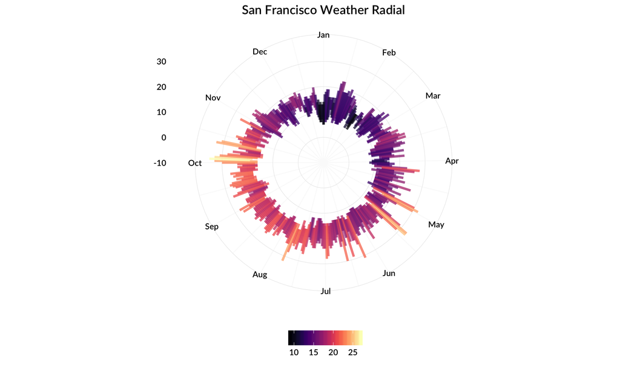

```r
library(ggplot2)
library(viridis)
library(scales)

ggplot(weather, aes(date2, ymin = min.temperaturec,
                    ymax = max.temperaturec, color = mean.temperaturec)) +
        geom_linerange(size = 1.3, alpha = 0.75) +
        scale_color_viridis(NULL, option = "A") +
        scale_x_date(labels = date_format("%b"),
                     breaks = date_breaks("month")) +
        ylim(-10, 35) +
        labs(title = "San Francisco Weather Radial",
             x = NULL, y = NULL) +
        coord_polar() +
        theme_minimal(base_family = "Lato Semibold") +
        theme(legend.position = "bottom")
```